# Création de la variable géographique

Enquête Envie

Auteur·rice

Affiliation

Arno Muller

Ined

Date de publication

18/04/2024

# Introduction

## Objectif

Ce document revient sur la création des indicateurs “géographiques” pour l’enquête Envie.  
Ces variables doivent être capable de rendre compte de plusieurs dimensions de la division spatiale :

- Caractériser les villes : en rural et urbain, tout en laissant possible de décliner cette opposition en plus de catégorie.
- Rendre compte de la densité de population à proximité, et notamment de jeunes

Pour permettre davantage de souplesse dans l’utilisation des indicateurs, le code ci-après doit être facilement modifiable pour adapter les variables créées à différents types d’analyses.

## Problèmes

Le principal problème pour la création de ces indicateurs est que l’enquête Envie interroge uniquement les codes postaux.

Ce qui posent un certains nombre de problème pour la création des indicateurs :

- Il existe très peu d’indicateurs calculés à cette échelle (l’INSEE utilise les codes communes).
- Le code postal est une unité très variable en taille mais aussi dans sa composition. Parfois, un code correspondra à une commune, parfois à un ensemble de communes ou à l’inverse une commune pourra regrouper plusieurs codes postaux.
- Certains codes postaux déclarés dans Envie n’existent pas réellement.

## Solution

Pour construire des “zones à façon” grâce aux données du carreau, une documentation détaillée est fournie par l’INSEE : ([lien](https://www.insee.fr/fr/statistiques/fichier/6215168/tutoriel_zone_a_facon.pdf))  
Nous reviendrons plus en détail sur le fonctionnement de la démarche dans la suite de ce document.

## Quels indicateurs ?

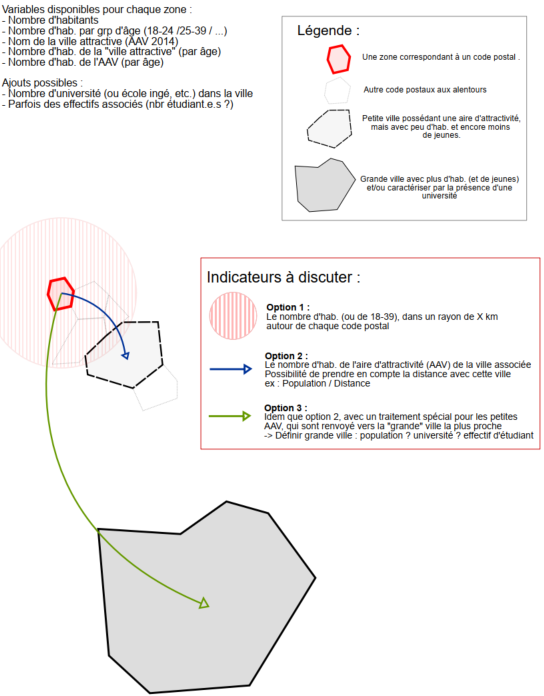

# Données

## Bases et sources

Pour construire les différents indicateurs, nous avons besoin de mobiliser plusieurs jeux de données:

**1) Les codes postaux** et leurs données spatiales

```r
postal <- st_read("Data/CodePostal/codes_postaux_region.shp",
                  options = "ENCODING=WINDOWS-1252", quiet = TRUE)
```

Source : https://www.data.gouv.fr/fr/datasets/fond-de-carte-des-codes-postaux

*Fond de carte des codes postaux :*

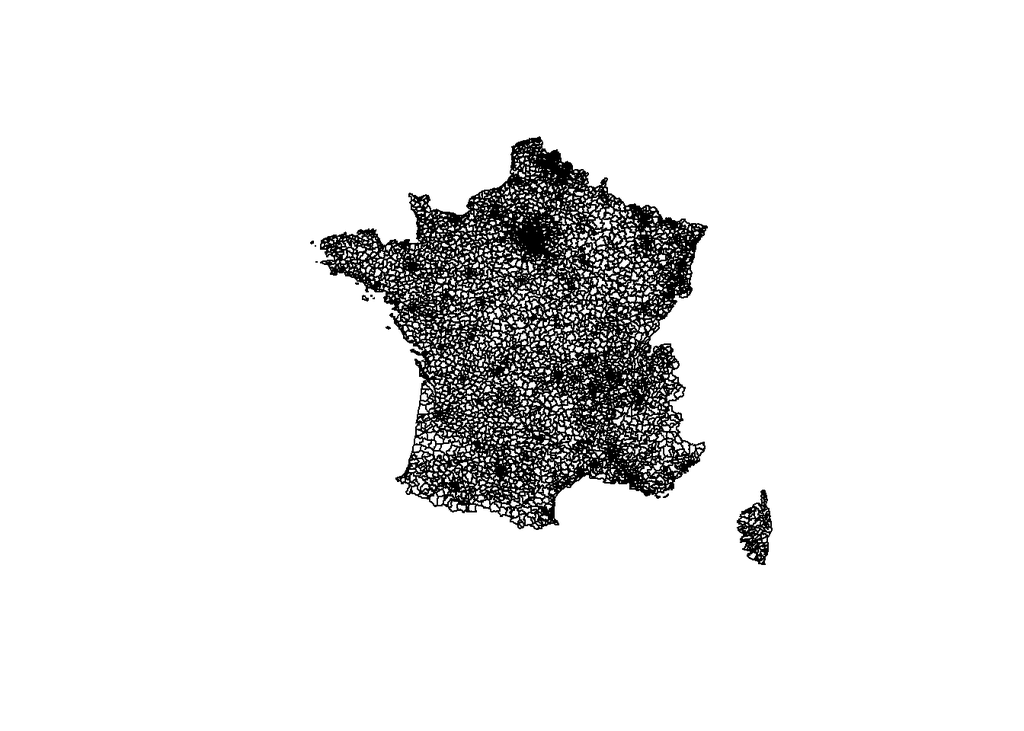

**2) Les données du carreaux**, qui nous permettent de créer des indicateurs fins (ici, sur le code postal)

```r
carreau <- st_read("Data/Carreaux/Filosofi2017_carreaux_200m_met.shp", quiet = TRUE)
```

Source : https://www.insee.fr/fr/statistiques/6215138?sommaire=6215217#dictionnaire

**3) La composition communale des Aires d’Attraction des Villes** (celle de 2014)

```r
AAV <- read.xlsx("Data/Aire_Ville/AAV2020_au_01-01-2014.xlsx",
                 sheet = 2,
                 startRow = 6)%>%
  # Nombre de communes dans l'AAV
  group_by(AAV2020)  %>%
  mutate(NCOM = n()) %>%
  ungroup()
```

Source : https://www.insee.fr/fr/information/4803954

**Note**

J’utilise la composition communale de 2014, qui a le plus de libéllés de communes en commun avec la base postale (faites en 2013).

**Astuce**

J’ai également fait le test avec la base des compositions des aires urbaines des villes. Un indicateur peut-être plus restrictif, mais beaucoup de communes sont “multi-pôles”, et ne sont donc pas associées à une ville, ce qui complique le calcul des distances.

Source : https://www.insee.fr/fr/information/2115011

**4) Les Codes Postaux présents dans Envie**

Je récupère la liste des codes postaux présents dans Envie, que j’ai extrait d’Envie. Ces données ne seront pas utilisée avant la fin du protocole.

```r
envie <- read.xlsx("Data/Envie/Envie_Post.xlsx")
```

## Fonctionnement de l’appariement

**1) A partir du carroyage**

Les données au carreau quadrille le territoire français en de petits carrés de 200m chacun. Chaque carreau devient donc une unité statistique sur laquelle on connait un certain nombre d’informations comme le nombre de ménages, d’individus, ou d’individus selon le groupe d’âge.

*Exemple de 10 carreaux :*

| Idcar_200m | I_est_200 | Idcar_1km | I_est_1km | Idcar_nat | Groupe | Ind | Men_1ind | Men_5ind | Men_prop | Men_fmp | Ind_snv | Men_surf | Men_coll | Men_mais | Log_av45 | Log_45_70 | Log_70_90 | Log_ap90 | Log_inc | Log_soc | Ind_0_3 | Ind_4_5 | Ind_6_10 | Ind_11_17 | Ind_18_24 | Ind_25_39 | Ind_40_54 | Ind_55_64 | Ind_65_79 | … |
| --- | --- | --- | --- | --- | --- | --- | --- | --- | --- | --- | --- | --- | --- | --- | --- | --- | --- | --- | --- | --- | --- | --- | --- | --- | --- | --- | --- | --- | --- | --- |
| CRS3035RES200mN2029800E4254200 | 1 | CRS3035RES1000mN2029000E4254000 | 1 | CRS3035RES8000mN2024000E4248000 | 14863 | 2 | 0.3 | 0.0 | 0.6 | 0.0 | 59349.4 | 145.1 | 0.1 | 0.8 | 0.0 | 0.0 | 0.4 | 0.5 | 0 | 0 | 0 | 0 | 0.0 | 0.3 | 0.2 | 0.0 | 0.4 | 0.3 | 0.7 | … |
| CRS3035RES200mN2030000E4254200 | 1 | CRS3035RES1000mN2030000E4254000 | 1 | CRS3035RES8000mN2024000E4248000 | 14863 | 1 | 0.2 | 0.0 | 0.3 | 0.0 | 29674.7 | 72.5 | 0.0 | 0.4 | 0.0 | 0.0 | 0.2 | 0.2 | 0 | 0 | 0 | 0 | 0.0 | 0.1 | 0.1 | 0.0 | 0.2 | 0.1 | 0.4 | … |
| CRS3035RES200mN2030000E4254600 | 1 | CRS3035RES1000mN2030000E4254000 | 1 | CRS3035RES8000mN2024000E4248000 | 14863 | 5 | 0.9 | 0.1 | 1.5 | 0.1 | 148373.6 | 362.7 | 0.2 | 2.0 | 0.1 | 0.0 | 0.9 | 1.2 | 0 | 0 | 0 | 0 | 0.0 | 0.6 | 0.4 | 0.1 | 1.1 | 0.7 | 1.8 | … |
| CRS3035RES200mN2030200E4254200 | 1 | CRS3035RES1000mN2030000E4254000 | 1 | CRS3035RES8000mN2024000E4248000 | 14863 | 3 | 0.5 | 0.1 | 0.9 | 0.1 | 89024.2 | 217.6 | 0.1 | 1.2 | 0.0 | 0.0 | 0.6 | 0.7 | 0 | 0 | 0 | 0 | 0.0 | 0.4 | 0.2 | 0.1 | 0.6 | 0.4 | 1.1 | … |
| CRS3035RES200mN2030400E4253800 | 1 | CRS3035RES1000mN2030000E4253000 | 1 | CRS3035RES8000mN2024000E4248000 | 175938 | 2 | 0.2 | 0.1 | 0.7 | 0.1 | 54304.3 | 111.4 | 0.1 | 0.8 | 0.0 | 0.1 | 0.2 | 0.6 | 0 | 0 | 0 | 0 | 0.1 | 0.1 | 0.0 | 0.2 | 0.6 | 0.5 | 0.4 | … |
| CRS3035RES200mN2030600E4251800 | 1 | CRS3035RES1000mN2030000E4251000 | 1 | CRS3035RES8000mN2024000E4248000 | 14863 | 4 | 0.7 | 0.1 | 1.2 | 0.1 | 118698.9 | 290.1 | 0.2 | 1.6 | 0.1 | 0.0 | 0.8 | 0.9 | 0 | 0 | 0 | 0 | 0.0 | 0.5 | 0.3 | 0.1 | 0.9 | 0.5 | 1.4 | … |
| CRS3035RES200mN2030600E4252200 | 1 | CRS3035RES1000mN2030000E4252000 | 1 | CRS3035RES8000mN2024000E4248000 | 175938 | 2 | 0.2 | 0.1 | 0.7 | 0.1 | 54304.3 | 111.4 | 0.1 | 0.8 | 0.0 | 0.1 | 0.2 | 0.6 | 0 | 0 | 0 | 0 | 0.1 | 0.1 | 0.0 | 0.2 | 0.6 | 0.5 | 0.4 | … |
| CRS3035RES200mN2030600E4253400 | 1 | CRS3035RES1000mN2030000E4253000 | 1 | CRS3035RES8000mN2024000E4248000 | 175938 | 5 | 0.4 | 0.1 | 1.7 | 0.3 | 135760.8 | 278.6 | 0.3 | 1.9 | 0.1 | 0.3 | 0.4 | 1.4 | 0 | 0 | 0 | 0 | 0.2 | 0.3 | 0.1 | 0.4 | 1.4 | 1.3 | 1.0 | … |
| CRS3035RES200mN2030600E4253600 | 1 | CRS3035RES1000mN2030000E4253000 | 1 | CRS3035RES8000mN2024000E4248000 | 175938 | 2 | 0.2 | 0.1 | 0.7 | 0.1 | 54304.3 | 111.4 | 0.1 | 0.8 | 0.0 | 0.1 | 0.2 | 0.6 | 0 | 0 | 0 | 0 | 0.1 | 0.1 | 0.0 | 0.2 | 0.6 | 0.5 | 0.4 | … |
| CRS3035RES200mN2030800E4252600 | 1 | CRS3035RES1000mN2030000E4252000 | 1 | CRS3035RES8000mN2024000E4248000 | 175938 | 4 | 0.3 | 0.1 | 1.3 | 0.2 | 108608.6 | 222.9 | 0.2 | 1.5 | 0.1 | 0.2 | 0.3 | 1.1 | 0 | 0 | 0 | 0 | 0.2 | 0.2 | 0.1 | 0.3 | 1.2 | 1.0 | 0.8 | … |

**2) Combiner avec le code postal**

Pour l’exemple, je fais la manipulation sur un code postal choisi au hasard : le 68400, Riedisheim, en Alsace.

1. Avec `st_join()`, j’isole chaque carreau se trouvant sur le territoire de Riedisheim :

```r
agregats_68400 <- carreau %>%
  st_join(postal[postal$ID == "68400",], join = st_intersects, left = FALSE)
```

|  | Idcar_200m | I_est_200 | Idcar_1km | I_est_1km | Idcar_nat | Groupe | Ind | Men_1ind | Men_5ind | Men_prop | Men_fmp | Ind_snv | Men_surf | Men_coll | Men_mais | Log_av45 | Log_45_70 | Log_70_90 | Log_ap90 | Log_inc | Log_soc | Ind_0_3 | Ind_4_5 | Ind_6_10 | Ind_11_17 | Ind_18_24 | Ind_25_39 | Ind_40_54 | Ind_55_64 | … |
| --- | --- | --- | --- | --- | --- | --- | --- | --- | --- | --- | --- | --- | --- | --- | --- | --- | --- | --- | --- | --- | --- | --- | --- | --- | --- | --- | --- | --- | --- | --- |
| 1342946 | CRS3035RES200mN2737200E4122200 | 1 | CRS3035RES1000mN2737000E4122000 | 1 | CRS3035RES2000mN2736000E4122000 | 301731 | 3.0 | 0.1 | 0.1 | 1.0 | 0.1 | 81242.8 | 150.4 | 0.0 | 1.0 | 0.2 | 0.0 | 0.3 | 0.5 | 0.0 | 0.0 | 0.1 | 0.0 | 0.2 | 0.6 | 0.3 | 0.2 | 0.9 | 0.2 | … |
| 1344160 | CRS3035RES200mN2737600E4121600 | 1 | CRS3035RES1000mN2737000E4121000 | 1 | CRS3035RES2000mN2736000E4120000 | 301732 | 1.0 | 0.1 | 0.0 | 0.4 | 0.1 | 32715.1 | 51.7 | 0.0 | 0.4 | 0.0 | 0.1 | 0.2 | 0.1 | 0.0 | 0.0 | 0.0 | 0.0 | 0.0 | 0.1 | 0.1 | 0.2 | 0.2 | 0.1 | … |
| 1344779 | CRS3035RES200mN2737800E4121800 | 1 | CRS3035RES1000mN2737000E4121000 | 1 | CRS3035RES2000mN2736000E4120000 | 301732 | 64.5 | 4.8 | 1.6 | 24.8 | 4.8 | 2110125.1 | 3337.2 | 3.2 | 24.0 | 3.2 | 5.6 | 10.4 | 8.0 | 0.0 | 0.0 | 2.4 | 0.4 | 2.8 | 2.8 | 6.4 | 12.0 | 13.7 | 8.8 | … |
| 1344780 | CRS3035RES200mN2737800E4122000 | 1 | CRS3035RES1000mN2737000E4122000 | 1 | CRS3035RES2000mN2736000E4122000 | 301731 | 20.5 | 0.8 | 0.4 | 6.9 | 0.8 | 555159.4 | 1027.4 | 0.0 | 6.9 | 1.6 | 0.0 | 1.6 | 3.7 | 0.0 | 0.0 | 0.4 | 0.0 | 1.2 | 4.1 | 2.4 | 1.2 | 6.3 | 1.6 | … |
| 1345365 | CRS3035RES200mN2738000E4121800 | 0 | CRS3035RES1000mN2738000E4121000 | 0 | CRS3035RES1000mN2738000E4121000 | 720843 | 62.0 | 9.0 | 2.0 | 19.0 | 0.0 | 2342282.1 | 3252.0 | 14.0 | 12.0 | 1.0 | 2.0 | 19.0 | 4.0 | 0.0 | 0.0 | 4.0 | 3.0 | 2.0 | 5.0 | 5.0 | 11.0 | 14.0 | 11.0 | … |
| 1345366 | CRS3035RES200mN2738000E4122000 | 0 | CRS3035RES1000mN2738000E4122000 | 1 | CRS3035RES2000mN2738000E4122000 | 720914 | 65.0 | 4.0 | 1.0 | 24.0 | 2.0 | 2487436.2 | 3549.0 | 1.0 | 25.0 | 3.0 | 5.0 | 9.0 | 9.0 | 0.0 | 0.0 | 0.0 | 1.0 | 3.0 | 4.0 | 7.0 | 7.0 | 8.0 | 18.0 | … |
| 1345367 | CRS3035RES200mN2738000E4122200 | 1 | CRS3035RES1000mN2738000E4122000 | 1 | CRS3035RES2000mN2738000E4122000 | 301734 | 24.0 | 2.1 | 0.4 | 5.1 | 0.0 | 708041.1 | 1067.1 | 4.2 | 5.1 | 0.8 | 1.3 | 0.4 | 6.4 | 0.4 | 0.0 | 0.9 | 0.4 | 1.5 | 2.1 | 1.3 | 5.9 | 6.8 | 3.0 | … |
| 1345954 | CRS3035RES200mN2738200E4121800 | 1 | CRS3035RES1000mN2738000E4121000 | 0 | CRS3035RES1000mN2738000E4121000 | 720837 | 22.0 | 2.1 | 0.8 | 5.8 | 0.6 | 878894.8 | 1176.7 | 1.7 | 6.8 | 0.8 | 1.3 | 3.6 | 2.8 | 0.0 | 0.2 | 0.2 | 0.6 | 0.8 | 2.6 | 2.4 | 3.0 | 4.3 | 4.5 | … |
| 1345955 | CRS3035RES200mN2738200E4122000 | 0 | CRS3035RES1000mN2738000E4122000 | 1 | CRS3035RES2000mN2738000E4122000 | 720913 | 50.0 | 5.0 | 0.0 | 19.0 | 0.0 | 2043775.1 | 2384.4 | 7.0 | 14.0 | 5.0 | 2.0 | 5.0 | 8.0 | 1.0 | 0.0 | 3.0 | 2.0 | 0.0 | 5.0 | 3.0 | 7.0 | 12.0 | 13.0 | … |
| 1345956 | CRS3035RES200mN2738200E4122200 | 1 | CRS3035RES1000mN2738000E4122000 | 1 | CRS3035RES2000mN2738000E4122000 | 301734 | 1.0 | 0.1 | 0.0 | 0.2 | 0.0 | 29501.7 | 44.5 | 0.2 | 0.2 | 0.0 | 0.1 | 0.0 | 0.3 | 0.0 | 0.0 | 0.0 | 0.0 | 0.1 | 0.1 | 0.1 | 0.2 | 0.3 | 0.1 | … |
| 1346500 | CRS3035RES200mN2738400E4122000 | 1 | CRS3035RES1000mN2738000E4122000 | 1 | CRS3035RES2000mN2738000E4122000 | 301734 | 17.0 | 1.5 | 0.3 | 3.6 | 0.0 | 501529.1 | 755.9 | 3.0 | 3.6 | 0.6 | 0.9 | 0.3 | 4.5 | 0.3 | 0.0 | 0.6 | 0.3 | 1.1 | 1.5 | 0.9 | 4.2 | 4.8 | 2.1 | … |
| 1347025 | CRS3035RES200mN2738600E4123800 | 1 | CRS3035RES1000mN2738000E4123000 | 1 | CRS3035RES2000mN2738000E4122000 | 301734 | 4.0 | 0.4 | 0.1 | 0.8 | 0.0 | 118006.9 | 177.8 | 0.7 | 0.9 | 0.1 | 0.2 | 0.1 | 1.1 | 0.1 | 0.0 | 0.1 | 0.1 | 0.2 | 0.4 | 0.2 | 1.0 | 1.1 | 0.5 | … |
| 1347565 | CRS3035RES200mN2738800E4123800 | 1 | CRS3035RES1000mN2738000E4123000 | 1 | CRS3035RES2000mN2738000E4122000 | 301734 | 10.5 | 0.9 | 0.2 | 2.2 | 0.0 | 309768.0 | 466.9 | 1.9 | 2.2 | 0.4 | 0.5 | 0.2 | 2.8 | 0.2 | 0.0 | 0.4 | 0.2 | 0.6 | 0.9 | 0.6 | 2.6 | 3.0 | 1.3 | … |
| 1347566 | CRS3035RES200mN2738800E4124000 | 1 | CRS3035RES1000mN2738000E4124000 | 0 | CRS3035RES1000mN2738000E4124000 | 720942 | 6.0 | 0.2 | 0.1 | 2.0 | 0.1 | 217319.0 | 282.1 | 0.1 | 2.1 | 0.4 | 1.2 | 0.6 | 0.0 | 0.0 | 0.0 | 0.1 | 0.0 | 0.4 | 0.5 | 0.6 | 0.4 | 1.3 | 1.4 | … |
| 1348148 | CRS3035RES200mN2739000E4123600 | 1 | CRS3035RES1000mN2739000E4123000 | 0 | CRS3035RES2000mN2738000E4122000 | 720928 | 7.5 | 0.6 | 0.0 | 2.8 | 0.6 | 245085.8 | 365.2 | 0.0 | 3.3 | 0.6 | 2.0 | 0.7 | 0.0 | 0.0 | 0.0 | 0.0 | 0.4 | 0.6 | 0.6 | 0.4 | 0.6 | 2.2 | 1.1 | … |
| 1348149 | CRS3035RES200mN2739000E4124000 | 1 | CRS3035RES1000mN2739000E4124000 | 0 | CRS3035RES1000mN2739000E4124000 | 720944 | 7.0 | 0.2 | 0.3 | 2.5 | 0.2 | 262335.9 | 347.6 | 0.1 | 2.5 | 0.0 | 0.1 | 1.7 | 0.8 | 0.0 | 0.0 | 0.3 | 0.0 | 0.0 | 0.5 | 1.2 | 0.6 | 1.5 | 1.6 | … |
| 1348709 | CRS3035RES200mN2739200E4122400 | 1 | CRS3035RES1000mN2739000E4122000 | 0 | CRS3035RES2000mN2738000E4122000 | 720915 | 12.0 | 2.1 | 0.3 | 3.3 | 0.3 | 443193.4 | 662.5 | 0.6 | 4.7 | 1.6 | 1.5 | 1.0 | 1.2 | 0.0 | 0.0 | 0.3 | 0.5 | 0.7 | 0.6 | 1.2 | 2.1 | 1.9 | 2.8 | … |
| 1348710 | CRS3035RES200mN2739200E4122800 | 1 | CRS3035RES1000mN2739000E4122000 | 0 | CRS3035RES2000mN2738000E4122000 | 720915 | 3.0 | 0.5 | 0.1 | 0.8 | 0.1 | 110798.4 | 165.6 | 0.1 | 1.2 | 0.4 | 0.4 | 0.2 | 0.3 | 0.0 | 0.0 | 0.1 | 0.1 | 0.2 | 0.1 | 0.3 | 0.5 | 0.5 | 0.7 | … |
| 1348711 | CRS3035RES200mN2739200E4123000 | 1 | CRS3035RES1000mN2739000E4123000 | 0 | CRS3035RES2000mN2738000E4122000 | 720928 | 6.0 | 0.4 | 0.0 | 2.2 | 0.4 | 196068.6 | 292.1 | 0.0 | 2.7 | 0.5 | 1.6 | 0.6 | 0.0 | 0.0 | 0.0 | 0.0 | 0.3 | 0.5 | 0.4 | 0.3 | 0.5 | 1.8 | 0.9 | … |
| 1348712 | CRS3035RES200mN2739200E4123200 | 1 | CRS3035RES1000mN2739000E4123000 | 0 | CRS3035RES2000mN2738000E4122000 | 720928 | 3.0 | 0.2 | 0.0 | 1.1 | 0.2 | 98034.3 | 146.1 | 0.0 | 1.3 | 0.2 | 0.8 | 0.3 | 0.0 | 0.0 | 0.0 | 0.0 | 0.1 | 0.3 | 0.2 | 0.2 | 0.2 | 0.9 | 0.4 | … |
| 1348713 | CRS3035RES200mN2739200E4123400 | 1 | CRS3035RES1000mN2739000E4123000 | 0 | CRS3035RES2000mN2738000E4122000 | 720928 | 9.0 | 0.7 | 0.0 | 3.3 | 0.7 | 294102.9 | 438.2 | 0.0 | 4.0 | 0.7 | 2.4 | 0.9 | 0.0 | 0.0 | 0.0 | 0.0 | 0.4 | 0.8 | 0.7 | 0.4 | 0.7 | 2.7 | 1.3 | … |
| 1349293 | CRS3035RES200mN2739400E4122400 | 0 | CRS3035RES1000mN2739000E4122000 | 0 | CRS3035RES2000mN2738000E4122000 | 720921 | 75.0 | 7.0 | 1.0 | 29.0 | 2.0 | 2801793.1 | 4604.0 | 3.0 | 30.0 | 1.0 | 4.0 | 17.0 | 11.0 | 0.0 | 0.0 | 0.0 | 2.0 | 3.0 | 6.0 | 4.0 | 4.0 | 15.0 | 16.0 | … |
| 1349294 | CRS3035RES200mN2739400E4122600 | 0 | CRS3035RES1000mN2739000E4122000 | 0 | CRS3035RES2000mN2738000E4122000 | 720920 | 55.5 | 6.0 | 2.0 | 24.0 | 1.0 | 2055475.1 | 3528.0 | 0.0 | 24.0 | 2.0 | 3.0 | 10.0 | 9.0 | 0.0 | 0.0 | 1.0 | 1.0 | 0.5 | 3.0 | 4.0 | 4.0 | 8.0 | 10.0 | … |
| 1349295 | CRS3035RES200mN2739400E4122800 | 1 | CRS3035RES1000mN2739000E4122000 | 0 | CRS3035RES2000mN2738000E4122000 | 720915 | 18.0 | 3.1 | 0.4 | 4.9 | 0.4 | 664790.1 | 993.8 | 0.9 | 7.1 | 2.4 | 2.2 | 1.6 | 1.8 | 0.0 | 0.0 | 0.4 | 0.7 | 1.1 | 0.9 | 1.8 | 3.1 | 2.9 | 4.2 | … |
| 1349296 | CRS3035RES200mN2739400E4123000 | 1 | CRS3035RES1000mN2739000E4123000 | 0 | CRS3035RES2000mN2738000E4122000 | 720928 | 15.0 | 1.1 | 0.0 | 5.6 | 1.1 | 490171.6 | 730.4 | 0.0 | 6.7 | 1.1 | 4.1 | 1.5 | 0.0 | 0.0 | 0.0 | 0.0 | 0.7 | 1.3 | 1.1 | 0.7 | 1.1 | 4.5 | 2.2 | … |
| 1349297 | CRS3035RES200mN2739400E4123200 | 0 | CRS3035RES1000mN2739000E4123000 | 0 | CRS3035RES2000mN2738000E4122000 | 720931 | 61.5 | 10.0 | 2.0 | 27.0 | 2.0 | 1818064.4 | 3347.0 | 0.0 | 29.0 | 2.0 | 6.0 | 20.0 | 1.0 | 0.0 | 0.0 | 4.0 | 0.0 | 2.5 | 1.0 | 4.0 | 6.0 | 9.0 | 10.0 | … |
| 1349298 | CRS3035RES200mN2739400E4123400 | 0 | CRS3035RES1000mN2739000E4123000 | 0 | CRS3035RES2000mN2738000E4122000 | 720935 | 83.0 | 8.0 | 2.0 | 31.0 | 3.0 | 3296995.0 | 4674.0 | 10.0 | 28.0 | 1.0 | 0.0 | 19.0 | 18.0 | 0.0 | 0.0 | 1.0 | 1.0 | 2.0 | 4.5 | 10.5 | 8.0 | 14.0 | 20.0 | … |
| 1349299 | CRS3035RES200mN2739400E4123600 | 0 | CRS3035RES1000mN2739000E4123000 | 0 | CRS3035RES2000mN2738000E4122000 | 720929 | 33.0 | 3.0 | 1.0 | 16.0 | 2.0 | 1163239.6 | 2015.0 | 4.0 | 12.0 | 0.0 | 9.0 | 6.0 | 1.0 | 0.0 | 0.0 | 0.0 | 1.0 | 0.0 | 1.0 | 0.0 | 3.0 | 2.0 | 5.0 | … |
| 1349905 | CRS3035RES200mN2739600E4122400 | 0 | CRS3035RES1000mN2739000E4122000 | 0 | CRS3035RES2000mN2738000E4122000 | 720919 | 63.0 | 8.0 | 1.0 | 16.0 | 1.0 | 2122401.8 | 2539.0 | 7.0 | 17.0 | 6.0 | 13.0 | 2.0 | 3.0 | 0.0 | 0.0 | 2.0 | 1.0 | 6.0 | 9.0 | 6.0 | 6.0 | 19.0 | 10.0 | … |
| 1349906 | CRS3035RES200mN2739600E4122600 | 0 | CRS3035RES1000mN2739000E4122000 | 0 | CRS3035RES2000mN2738000E4122000 | 720923 | 109.0 | 8.0 | 3.0 | 33.0 | 3.0 | 3808662.9 | 5008.0 | 7.0 | 36.0 | 21.0 | 8.0 | 7.0 | 7.0 | 0.0 | 0.0 | 3.0 | 1.0 | 4.0 | 9.0 | 14.0 | 4.0 | 36.0 | 20.0 | … |

[output cut: 91 more lines]

*Pour chaque carreau, je connais le nombre de personne âgées de 18 à 39ans.*

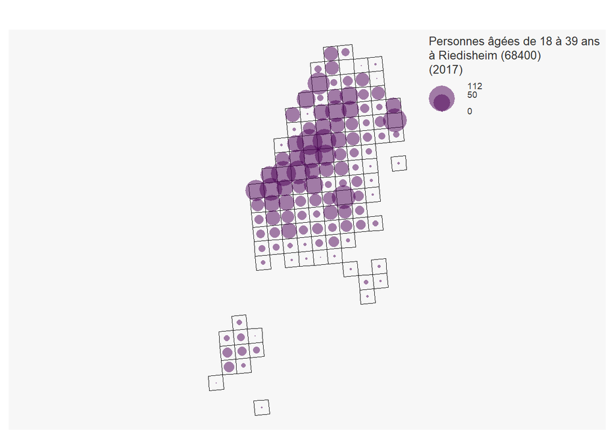

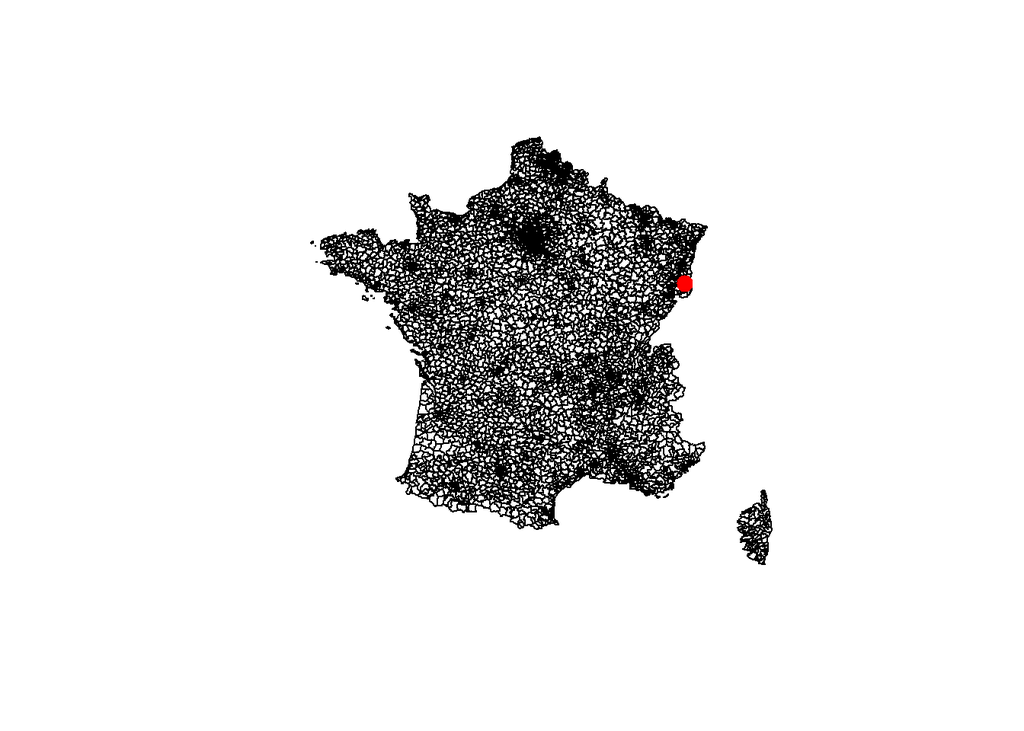

2. J’aggrège les données pour obtenir des indicateurs à l’échelle du code postal.

```r
agregats_68400_agg <- agregats_68400     %>%
  st_set_geometry(NULL)                  %>%
  select(Ind, Men, Ind_18_24, Ind_25_39) %>%
  summarise_all(sum)                     %>%
  mutate(Ind_18_39 = Ind_18_24 + Ind_25_39,
         Prop_18_39 = Ind_18_39*100 / Ind)
```

| Ind | Men | Ind_18_24 | Ind_25_39 | Ind_18_39 | Prop_18_39 |
| --- | --- | --- | --- | --- | --- |
| 13255 | 6407.7 | 970 | 2230.8 | 3200.8 | 24.14787 |

# Harmonisation et jointures

Pour joindre les différentes bases de données, je dois m’assurer que les clés d’appariements (noms de communes, département, etc.) soient similaires.  
Durant cette étape, deux éléments doivent être corrigés :

- Les départements de la Corse sont mal renseignés dans la base des codes postaux : 20 au lieu de 2A et 2B.
- Les libellés des communes ne sont pas toujours orthographiés de la même manière dans la base des aires d’attractivités des villes.

## Le cas Corse

1. Je commence par récupérer les bons départements depuis la base des AAV.

```r
Corse <-  AAV %>%
  filter(DEP %in% c("2A","2B")) %>%
  select(LIBGEO, DEP) %>%
  rename(DEP_corse = DEP)
```

2. Je corrige les département dans la base postale :

```r
postal2 <- postal %>%
  left_join(Corse, by = c("LIB" = "LIBGEO")) %>%
  mutate(DEP = ifelse(is.na(DEP_corse), DEP, DEP_corse)) %>%
  select(-DEP_corse)
```

3. Des petites communes sont présentes dans la bases postales, mais ne sont pas renseignées dans la base des AAV. Nous devons donc leurs attribuer un code de département.

**Note**

Il s’agit souvent de quartier d’une commune déjà présente, dans ce cas, je les recode par le nom de cette commune et leur attribue le même département.

```r
LIB_Corse_manq <-c("Rogliano","Vico","Brando","Sainte-Lucie-de-Porto-Vecchio",
                   "Grosseto-Prugna","Ajaccio","Penta-di-Casinca","Morosaglia",
                   "La Porta")
DEP_Corse_manq <- c("2B","2A","2B","2A","2A","2A","2B","2B","2B")

Corse_manq <- postal2 %>%
  filter(DEP == "20") %>%
  mutate(DEP = DEP_Corse_manq) %>%
  mutate(LIB = LIB_Corse_manq)

postal2 <- postal2 %>%
  filter(DEP != "20") %>%
  bind_rows(Corse_manq)
```

**Aparté sur *Sainte-Lucie-de-Porto-Vecchio**

Je n’ai pas vérifié pour toutes les communes, mais pour *“Sainte-Lucie-de-Porto-Vecchio”*, la ville théoriquement associée : Zonza se trouvent à environ 1h de route. J’ai donc préféré la laisser comme commune seule, et ajouter une ligne dans la base des Aires des attractivités des villes (AAV)

```r
St_lucie_AAV <- data.frame(CODGEO = "2A362",
                           LIBGEO = "Sainte-Lucie-de-Porto-Vecchio",
                           AAV2020 = "298",
                           LIBAAV2020 = "Porto-Vecchio",
                           CATEAAV2020 = 20,
                           DEP = "2A",
                           REG = 94,
                           NCOM = 10)

AAV <- AAV %>%
  bind_rows(St_lucie_AAV)
```

## Fusion des bases postales et du carroyage

Maintenant que les départements sont similaires entre les deux bases, je peux les fusionner.

**Attention**

Cette étape demande beaucoup de mémoire pour l’ordinateur, il peut être utile de supprimer les éléments inutiles de l’environnement.  
De plus, je m’y prend en deux fois, pour alléger le processus.

1. **Attribution du code postal à chaque carreau**

```r
carreau1 <- carreau[c(1:(nrow(carreau)/2)),]
carreau2 <- carreau[c(1147389:(nrow(carreau))),]
rm(carreau)
```

```r
carreau1 <- st_join(carreau1, postal2, join = st_intersects, left = FALSE)
carreau2 <- st_join(carreau2, postal2, join = st_intersects, left = FALSE)
```

```r
carreau_post <- bind_rows(carreau1,carreau2)
rm(carreau1, carreau2)
```

2. **Aggrégation des données à l’intérieur de chaque code postaux**

```r
agregatsZaf <- carreau_post %>%
  st_set_geometry(NULL)     %>%
  group_by(ID, LIB, DEP)    %>%
  summarise(Ind = sum(Ind),
            Men = sum(Men),
            Ind_18_24 = sum(Ind_18_24),
            Ind_25_39 = sum(Ind_25_39))      %>%
  mutate(Ind_18_39 = Ind_18_24 + Ind_25_39,
         Prop_18_39 = Ind_18_39 * 100 / Ind) %>%
  # Je nettoie les noms avec deux espaces
  mutate(LIB = gsub("  "," ", LIB))          %>%
  ungroup()
rm(carreau_post)
```

| ID | LIB | DEP | Ind | Men | Ind_18_24 | Ind_25_39 | Ind_18_39 | Prop_18_39 |
| --- | --- | --- | --- | --- | --- | --- | --- | --- |
| 01000 | Bourg-en-Bresse | 01 | 45498.5 | 21919.8 | 3799.9 | 7967.3 | 11767.2 | 25.86283 |
| 01090 | Montmerle-sur-Saône | 01 | 9195.5 | 3533.2 | 629.3 | 1499.7 | 2129.0 | 23.15263 |
| 01100 | Oyonnax | 01 | 33632.0 | 13682.3 | 2567.8 | 5878.7 | 8446.5 | 25.11447 |
| 01110 | Hauteville-Lompnes | 01 | 5634.5 | 2711.4 | 366.6 | 863.2 | 1229.8 | 21.82625 |
| 01120 | Montluel | 01 | 19145.0 | 7325.1 | 1557.3 | 3579.3 | 5136.6 | 26.82998 |
| 01130 | Nantua | 01 | 6801.0 | 2931.8 | 494.0 | 1201.0 | 1695.0 | 24.92281 |
| 01140 | Thoissey | 01 | 8710.5 | 3556.8 | 699.9 | 1527.2 | 2227.1 | 25.56799 |
| 01150 | Lagnieu | 01 | 18523.5 | 7720.7 | 1383.6 | 3569.4 | 4953.0 | 26.73901 |
| 01160 | Pont-d'Ain | 01 | 10164.5 | 4177.6 | 678.8 | 1832.3 | 2511.1 | 24.70461 |
| 01170 | Gex | 01 | 25567.0 | 10414.1 | 1968.7 | 6034.2 | 8002.9 | 31.30168 |

**Conclusion**

J’obtiens une base des codes postaux, avec des mesures de la population à la bonne échelle et fusionnable avec Envie.

## Ajout des aires d’attractivités des villes

La base des Aires d’attractivité des villes (AAV), nous donne pour chaque commune française, la “grande ville attractive” qui lui est associée.

| CODGEO | LIBGEO | AAV2020 | LIBAAV2020 | CATEAAV2020 | DEP | REG | NCOM |
| --- | --- | --- | --- | --- | --- | --- | --- |
| 01001 | L'Abergement-Clémenciat | 524 | Châtillon-sur-Chalaronne | 20 | 01 | 82 | 5 |
| 01002 | L'Abergement-de-Varey | 000 | Commune hors attraction des villes | 30 | 01 | 82 | 9396 |
| 01004 | Ambérieu-en-Bugey | 243 | Ambérieu-en-Bugey | 11 | 01 | 82 | 15 |
| 01005 | Ambérieux-en-Dombes | 002 | Lyon | 20 | 01 | 82 | 410 |
| 01006 | Ambléon | 286 | Belley | 20 | 01 | 82 | 37 |
| 01007 | Ambronay | 243 | Ambérieu-en-Bugey | 20 | 01 | 82 | 15 |
| 01008 | Ambutrix | 243 | Ambérieu-en-Bugey | 20 | 01 | 82 | 15 |
| 01009 | Andert-et-Condon | 286 | Belley | 20 | 01 | 82 | 37 |
| 01010 | Anglefort | 000 | Commune hors attraction des villes | 30 | 01 | 82 | 9396 |
| 01011 | Apremont | 168 | Oyonnax | 20 | 01 | 82 | 42 |

On joint cette information à notre base des codes postaux :

```r
agregatsZaf <- agregatsZaf %>%
  left_join(AAV, by = c("LIB" = "LIBGEO", "DEP"))
```

**Avertissement**

Il y a beaucoup de valeurs manquantes, comme toutes les villes ne sont pas toujours orthographiées de la même manière (ou n’existe pas) dans les deux fichiers.  
**Il faut les recoder à la main !**

## Correction des noms des libellés … à la main

1. **Je crée un document Excel** avec les villes non-reconnues dans la base des AAV.

```r
agregatsZaf_NA1 <- agregatsZaf %>%
  filter(is.na(NCOM) & is.na(Ind) == F) %>%
  select(ID, LIB, DEP)

write.xlsx(agregatsZaf_NA1, "agregatsZaf_NA1.xlsx")
```

2. **Je recode à la main** toutes les villes pour qu’elles correspondent à une ville de la base AAV. J’obtiens le fichier *agregatsZaf_NA1_Complet.xlsx*.
3. **J’effectue la jointure** en tenant compte du recodage issue de *agregatsZaf_NA1_Complet.xlsx*.

```r
agregatsZaf_NA1_C <- read.xlsx("Data/Apurement/agregatsZaf_NA1_Complet.xlsx")

agregatsZaf2 <- agregatsZaf    %>%
  left_join(agregatsZaf_NA1_C) %>%
  mutate(LIB = if_else(is.na(RECODAGE),LIB, RECODAGE)) %>%
  select(1:9) %>%
  left_join(AAV, by = c("LIB" = "LIBGEO", "DEP"))
```

| ID | LIB | DEP | Ind | Men | Ind_18_24 | Ind_25_39 | Ind_18_39 | Prop_18_39 | CODGEO | AAV2020 | LIBAAV2020 | CATEAAV2020 | REG | NCOM |
| --- | --- | --- | --- | --- | --- | --- | --- | --- | --- | --- | --- | --- | --- | --- |
| 01000 | Bourg-en-Bresse | 01 | 45498.5 | 21919.8 | 3799.9 | 7967.3 | 11767.2 | 25.86283 | 01053 | 080 | Bourg-en-Bresse | 11 | 82 | 87 |
| 01090 | Montmerle-sur-Saône | 01 | 9195.5 | 3533.2 | 629.3 | 1499.7 | 2129.0 | 23.15263 | 01263 | 000 | Commune hors attraction des villes | 30 | 82 | 9396 |
| 01100 | Oyonnax | 01 | 33632.0 | 13682.3 | 2567.8 | 5878.7 | 8446.5 | 25.11447 | 01283 | 168 | Oyonnax | 11 | 82 | 42 |
| 01110 | Hauteville-Lompnes | 01 | 5634.5 | 2711.4 | 366.6 | 863.2 | 1229.8 | 21.82625 | 01185 | 572 | Plateau d'Hauteville | 11 | 82 | 10 |
| 01120 | Montluel | 01 | 19145.0 | 7325.1 | 1557.3 | 3579.3 | 5136.6 | 26.82998 | 01262 | 002 | Lyon | 20 | 82 | 410 |
| 01130 | Nantua | 01 | 6801.0 | 2931.8 | 494.0 | 1201.0 | 1695.0 | 24.92281 | 01269 | 000 | Commune hors attraction des villes | 30 | 82 | 9396 |
| 01140 | Thoissey | 01 | 8710.5 | 3556.8 | 699.9 | 1527.2 | 2227.1 | 25.56799 | 01420 | 638 | Saint-Didier-sur-Chalaronne | 12 | 82 | 2 |
| 01150 | Lagnieu | 01 | 18523.5 | 7720.7 | 1383.6 | 3569.4 | 4953.0 | 26.73901 | 01202 | 505 | Lagnieu | 11 | 82 | 3 |
| 01160 | Pont-d'Ain | 01 | 10164.5 | 4177.6 | 678.8 | 1832.3 | 2511.1 | 24.70461 | 01304 | 000 | Commune hors attraction des villes | 30 | 82 | 9396 |
| 01170 | Gex | 01 | 25567.0 | 10414.1 | 1968.7 | 6034.2 | 8002.9 | 31.30168 | 01173 | GEN | Genève - Annemasse (partie française) | 20 | 82 | 161 |

**Conclusion**

J’ai ajouté pour chaque code postal, des informations sur la ville de référence (variable : *LIBAAV2020*) en terme d’aire d’attractivité des villes (AAV).

# Création des indicateurs

Dans cette partie, nous revenons sur les différents indicateurs permettant de capter des différences spatiales et leurs constructions.

Nous pouvons regrouper ces indicateurs en 3 catégories :

- Les indicateurs simples de **densité** de population à proximité (déclinée selon l’âge) :  
  → Population du code postal d’habitation  
  → Population de la ville de référence selon l’aire d’attraction des villes  
  → Population total de l’AAV (ville de référence + autres communes affiliées)
- Les indicateurs simples de **distance** au centre urbain :  
  → Distance à la ville de référence (en km).  
  → Distance à un premier grand centre urbain (métropole ?).

**Note**

Dans ce cas, il faut définir des critères de “grandes villes” : un pallier de population, la présence d’une (ou plusieurs) université (qu’on peut pondérer par le nombre d’étudiant·es)

- Les indicateurs qui mixent **population et distance** :  
  → Somme des populations des codes postaux dans un rayon de Xkm autour de chaque territoire.  
  → Population totale de l’AAV / Distance à l’AAV  
  → Population du centre urbain / Distance à ce centre urbain

## Indicateurs de populations

Pour l’instant, nous avons la population de chaque code postal, nous allons y ajouter d’autres variables :

### Population de la ville de référence (AAV)

Nous continuons avec les recodages des noms de villes, mais cette fois-ci pour les noms de villes de référence dans l’AAV.  
Ces noms posent plusieurs problèmes pour la création des indicateurs à l’échelle des AAV :

- Des *LIBAAV2020* regroupent deux noms de communes et n’ont donc pas d’équivalent dans les noms de codes postaux (ex : Aix-Marseille)
- Des villes ont des homonymes dans d’autres département (comme Valence).
- Des libellés de villes de référence (variable *LIBAAV2020*) sont orthographiés différemment que dans la variable *LIB*.
- Des *LIBAAV2020* n’existent pas dans les codes postaux à disposition (fusion asministratives de communes, etc.)
- Des AAV sont partagées entre plusieurs pays, je n’ai donc pas les informations pour les villes étrangères.

#### 1) Correction des AAV regroupant deux villes en France

→ Je calcule la population totale au sein des deux villes.

```r
AAV_partage <- agregatsZaf2 %>%
  filter(LIB %in% c("Marseille", "Aix-en-Provence", "Lille",
                    "Strasbourg", "Antibes", "Cannes",
                    "Cherbourg-Octeville", "Lens",
                    "Valenciennes", "Bayonne", "Maubeuge", "Monaco",
                    "Menton", "Sarreguemines","Briey", "Auchel", "Lillers", "Vire",
                    "Pleyben", "Châteaulin", "Amnéville", "Rombas", "Arcachon",
                    "La Teste-de-Buch","Biars-sur-Cère", "Saint-Céré",
                    "Delle", "Forbach", "Nonancourt", "Saint-Lubin-des-Joncherets",
                    "Roscoff", "Saint-Pol-de-Léon", "Saint-Avold", "Saint-Satur",
                    "Sancerre", "Verneuil-sur-Avre", "Villedieu-les-Poêles", "Vittel",
                    "Contrexéville","Étaples", "Le Touquet-Paris-Plage")) %>%
  select(LIBAAV2020, DEP, Ind, Ind_18_24, Ind_25_39, Ind_18_39) %>%
  rename(Ville_Ind = Ind,
         Ville_Ind_18_24 = Ind_18_24,
         Ville_Ind_25_39 = Ind_25_39,
         Ville_Ind_18_39 = Ind_18_39) %>%
  group_by(LIBAAV2020) %>%
  summarise_if(is.numeric,sum) %>%
  distinct()
# %>% left_join(select(agregatsZaf2, ID, LIBAAV2020), by = "LIBAAV2020")
```

#### 2) Calcule de la population des villes

1. *Je corrige l’orthographe des LIBAAV2020 qui n’ont pas d’équivalent dans LIB*

```r
agregatsZaf2 <- agregatsZaf2 %>%
  mutate(LIBAAV2020 = case_when(
    LIBAAV2020 == "Ancenis-Saint-Géréon" ~ "Ancenis",
    LIBAAV2020 == "Chemillé-en-Anjou" ~ "Chemillé-Melay",
    LIBAAV2020 == "La Ferté Macé" ~ "La Ferté-Macé",
    LIBAAV2020 == "Segré-en-Anjou Bleu" ~ "Segré",
    LIBAAV2020 == "Château-Gontier-sur-Mayenne" ~ "Château-Gontier",
    LIBAAV2020 == "Condé-en-Normandie" ~ "Condé-sur-Noireau",
    LIBAAV2020 == "Marennes-Hiers-Brouage" ~ "Marennes",
    LIBAAV2020 == "Aime-la-Plagne" ~ "Aime",
    LIBAAV2020 == "Argentat-sur-Dordogne" ~ "Argentat",
    LIBAAV2020 == "Belleville-en-Beaujolais" ~ "Belleville",
    LIBAAV2020 == "Carentan-les-Marais" ~ "Carentan",
    LIBAAV2020 == "Cours" ~ "Cours-la-Ville",
    LIBAAV2020 == "Domfront en Poiraie" ~ "Domfront",
    LIBAAV2020 == "Doué-en-Anjou" ~ "Doué-la-Fontaine",
    LIBAAV2020 == "Essarts en Bocage" ~ "Les Essarts",
    LIBAAV2020 == "Les Abrets en Dauphiné" ~ "Les Abrets",
    LIBAAV2020 == "Machecoul-Saint-Même" ~ "Machecoul",
    LIBAAV2020 == "Montrichard Val de Cher" ~ "Montrichard",
    LIBAAV2020 == "Morcenx-la-Nouvelle" ~ "Morcenx",
    LIBAAV2020 == "Plateau d'Hauteville" ~ "Hauteville-Lompnes",
    LIBAAV2020 == "Valgelon-La Rochette" ~ "La Rochette",
    LIBAAV2020 == "Ciboure"~ "Bayonne (partie française)",

    TRUE~ LIBAAV2020
  )) %>%
  mutate(LIB = case_when(
    LIB == "Saint-Hilaire-de-Loulay"~ "Montaigu-Vendée",
    LIB == "Morez"~ "Hauts de Bienne",
    LIB == "Vertus"~ "Blancs-Coteaux",
    LIB == "Collinée"~ "Le Mené",
    LIB == "Château-du-Loir"~ "Montval-sur-Loir",
    LIB == "Sainte-Foy-la-Grande"~ "Pineuilh",
    LIB == "Thoissey"~ "Saint-Didier-sur-Chalaronne",
    LIBAAV2020 == "Mauges-sur-Loire" ~ "Mauges-sur-Loire",
    TRUE~ LIB
  ))
```

1. *Je crée une base des villes de références selon l’AAV* :

```r
VilleAAV <- agregatsZaf2    %>%
  filter(LIB == LIBAAV2020) %>%
  select(LIB, LIBAAV2020, DEP, Ind, Ind_18_24, Ind_25_39, Ind_18_39) %>%
  rename(Ville_Ind = Ind,
         Ville_Ind_18_24 = Ind_18_24,
         Ville_Ind_25_39 = Ind_25_39,
         Ville_Ind_18_39 = Ind_18_39)
```

2. *Je modifie le nom des villes ayant des homonymes (en ajoutant le département).*

```r
VilleAAV <- VilleAAV %>%
  mutate(LIBAAV2020 = if_else(LIB == "Valence", paste(LIB,DEP, sep = "_"), LIBAAV2020),
         LIBAAV2020 = if_else(LIB == "Le Pont-de-Beauvoisin", paste(LIB,DEP, sep = "_"), LIBAAV2020))
```

3. *J’aggrège les données pour chaque ville*

```r
VilleAAV <- VilleAAV %>%
  distinct() %>%
  group_by(LIB, LIBAAV2020, DEP) %>%
  summarise_all(sum) %>%
  ungroup() %>%
  bind_rows(AAV_partage) %>%
  select(-c(LIB,DEP))
```

4. *Je fusionne avec les données par code postal*

```r
Envie_Geo <- agregatsZaf2 %>%
  mutate(LIBAAV2020 = case_when(
    LIBAAV2020 == "Valence" & DEP %in% c("26","07") ~ "Valence_26",
    LIBAAV2020 == "Valence" & DEP %in% c("82") ~ "Valence_82",
    LIBAAV2020 == "Le Pont-de-Beauvoisin" & DEP %in% c("38") ~ "Le Pont-de-Beauvoisin_38",
    LIBAAV2020 == "Le Pont-de-Beauvoisin" & DEP %in% c("73") ~ "Le Pont-de-Beauvoisin_73",
    TRUE~ LIBAAV2020
  )) %>%
  left_join(VilleAAV, by = c("LIBAAV2020"="LIBAAV2020"))
```

| ID | LIB | DEP | Ind | Men | Ind_18_24 | Ind_25_39 | Ind_18_39 | Prop_18_39 | CODGEO | AAV2020 | LIBAAV2020 | CATEAAV2020 | REG | NCOM | Ville_Ind | Ville_Ind_18_24 | Ville_Ind_25_39 | Ville_Ind_18_39 |
| --- | --- | --- | --- | --- | --- | --- | --- | --- | --- | --- | --- | --- | --- | --- | --- | --- | --- | --- |
| 01000 | Bourg-en-Bresse | 01 | 45498.5 | 21919.8 | 3799.9 | 7967.3 | 11767.2 | 25.86283 | 01053 | 080 | Bourg-en-Bresse | 11 | 82 | 87 | 45498.5 | 3799.9 | 7967.3 | 11767.2 |
| 01090 | Montmerle-sur-Saône | 01 | 9195.5 | 3533.2 | 629.3 | 1499.7 | 2129.0 | 23.15263 | 01263 | 000 | Commune hors attraction des villes | 30 | 82 | 9396 | NA | NA | NA | NA |
| 01100 | Oyonnax | 01 | 33632.0 | 13682.3 | 2567.8 | 5878.7 | 8446.5 | 25.11447 | 01283 | 168 | Oyonnax | 11 | 82 | 42 | 33632.0 | 2567.8 | 5878.7 | 8446.5 |
| 01110 | Hauteville-Lompnes | 01 | 5634.5 | 2711.4 | 366.6 | 863.2 | 1229.8 | 21.82625 | 01185 | 572 | Hauteville-Lompnes | 11 | 82 | 10 | 5634.5 | 366.6 | 863.2 | 1229.8 |
| 01120 | Montluel | 01 | 19145.0 | 7325.1 | 1557.3 | 3579.3 | 5136.6 | 26.82998 | 01262 | 002 | Lyon | 20 | 82 | 410 | 548688.0 | 46212.2 | 148399.2 | 194611.4 |
| 01130 | Nantua | 01 | 6801.0 | 2931.8 | 494.0 | 1201.0 | 1695.0 | 24.92281 | 01269 | 000 | Commune hors attraction des villes | 30 | 82 | 9396 | NA | NA | NA | NA |
| 01140 | Saint-Didier-sur-Chalaronne | 01 | 8710.5 | 3556.8 | 699.9 | 1527.2 | 2227.1 | 25.56799 | 01420 | 638 | Saint-Didier-sur-Chalaronne | 12 | 82 | 2 | 8710.5 | 699.9 | 1527.2 | 2227.1 |
| 01150 | Lagnieu | 01 | 18523.5 | 7720.7 | 1383.6 | 3569.4 | 4953.0 | 26.73901 | 01202 | 505 | Lagnieu | 11 | 82 | 3 | 18523.5 | 1383.6 | 3569.4 | 4953.0 |
| 01160 | Pont-d'Ain | 01 | 10164.5 | 4177.6 | 678.8 | 1832.3 | 2511.1 | 24.70461 | 01304 | 000 | Commune hors attraction des villes | 30 | 82 | 9396 | NA | NA | NA | NA |
| 01170 | Gex | 01 | 25567.0 | 10414.1 | 1968.7 | 6034.2 | 8002.9 | 31.30168 | 01173 | GEN | Genève - Annemasse (partie française) | 20 | 82 | 161 | NA | NA | NA | NA |

**A discuter : les AAV internationaux**

Listes des AAV sans informations complètes.

```r
AAV_incomplet <- filter(Envie_Geo, is.na(Ville_Ind)) %>%
  group_by(LIBAAV2020) %>%
  summarise(Eff= n()) %>%
  arrange(desc(Eff))
```

### Population totale de l’AAV

1. **J’aggrège les données pour chaque AAV**

```r
Indic_AAV <- Envie_Geo %>%
  select(LIBAAV2020, Ind, Ind_18_24, Ind_25_39, Ind_18_39) %>%
  rename(AAV_Ind = Ind,
         AAV_Ind_18_24 = Ind_18_24,
         AAV_Ind_25_39 = Ind_25_39,
         AAV_Ind_18_39 = Ind_18_39) %>%
  distinct() %>%
  group_by(LIBAAV2020) %>%
  summarise_all(sum) %>%
  ungroup()
```

2. **J’ajoute les indicateurs**

```r
Envie_Geo <- Envie_Geo %>%
  left_join(Indic_AAV, by = c("LIBAAV2020"="LIBAAV2020"))
```

| ID | LIB | DEP | Ind | Men | Ind_18_24 | Ind_25_39 | Ind_18_39 | Prop_18_39 | CODGEO | AAV2020 | LIBAAV2020 | CATEAAV2020 | REG | NCOM | Ville_Ind | Ville_Ind_18_24 | Ville_Ind_25_39 | Ville_Ind_18_39 | AAV_Ind | AAV_Ind_18_24 | AAV_Ind_25_39 | AAV_Ind_18_39 |
| --- | --- | --- | --- | --- | --- | --- | --- | --- | --- | --- | --- | --- | --- | --- | --- | --- | --- | --- | --- | --- | --- | --- |
| 01000 | Bourg-en-Bresse | 01 | 45498.5 | 21919.8 | 3799.9 | 7967.3 | 11767.2 | 25.86283 | 01053 | 080 | Bourg-en-Bresse | 11 | 82 | 87 | 45498.5 | 3799.9 | 7967.3 | 11767.2 | 126906.0 | 9928.7 | 21205.6 | 31134.3 |
| 01090 | Montmerle-sur-Saône | 01 | 9195.5 | 3533.2 | 629.3 | 1499.7 | 2129.0 | 23.15263 | 01263 | 000 | Commune hors attraction des villes | 30 | 82 | 9396 | NA | NA | NA | NA | 4077899.0 | 255405.3 | 594545.5 | 849950.8 |
| 01100 | Oyonnax | 01 | 33632.0 | 13682.3 | 2567.8 | 5878.7 | 8446.5 | 25.11447 | 01283 | 168 | Oyonnax | 11 | 82 | 42 | 33632.0 | 2567.8 | 5878.7 | 8446.5 | 51098.5 | 3953.7 | 8724.6 | 12678.3 |
| 01110 | Hauteville-Lompnes | 01 | 5634.5 | 2711.4 | 366.6 | 863.2 | 1229.8 | 21.82625 | 01185 | 572 | Hauteville-Lompnes | 11 | 82 | 10 | 5634.5 | 366.6 | 863.2 | 1229.8 | 5634.5 | 366.6 | 863.2 | 1229.8 |
| 01120 | Montluel | 01 | 19145.0 | 7325.1 | 1557.3 | 3579.3 | 5136.6 | 26.82998 | 01262 | 002 | Lyon | 20 | 82 | 410 | 548688.0 | 46212.2 | 148399.2 | 194611.4 | 2332543.5 | 186708.0 | 489419.1 | 676127.1 |
| 01130 | Nantua | 01 | 6801.0 | 2931.8 | 494.0 | 1201.0 | 1695.0 | 24.92281 | 01269 | 000 | Commune hors attraction des villes | 30 | 82 | 9396 | NA | NA | NA | NA | 4077899.0 | 255405.3 | 594545.5 | 849950.8 |
| 01140 | Saint-Didier-sur-Chalaronne | 01 | 8710.5 | 3556.8 | 699.9 | 1527.2 | 2227.1 | 25.56799 | 01420 | 638 | Saint-Didier-sur-Chalaronne | 12 | 82 | 2 | 8710.5 | 699.9 | 1527.2 | 2227.1 | 8710.5 | 699.9 | 1527.2 | 2227.1 |
| 01150 | Lagnieu | 01 | 18523.5 | 7720.7 | 1383.6 | 3569.4 | 4953.0 | 26.73901 | 01202 | 505 | Lagnieu | 11 | 82 | 3 | 18523.5 | 1383.6 | 3569.4 | 4953.0 | 18523.5 | 1383.6 | 3569.4 | 4953.0 |
| 01160 | Pont-d'Ain | 01 | 10164.5 | 4177.6 | 678.8 | 1832.3 | 2511.1 | 24.70461 | 01304 | 000 | Commune hors attraction des villes | 30 | 82 | 9396 | NA | NA | NA | NA | 4077899.0 | 255405.3 | 594545.5 | 849950.8 |
| 01170 | Gex | 01 | 25567.0 | 10414.1 | 1968.7 | 6034.2 | 8002.9 | 31.30168 | 01173 | GEN | Genève - Annemasse (partie française) | 20 | 82 | 161 | NA | NA | NA | NA | 396007.5 | 28411.7 | 86067.7 | 114479.4 |

**Conclusion**

J’ai désormais des informations sur :

- La population des codes postaux (et selon l’âge) :  
  → *Ind*, *Ind_18_24*, *Ind_25_39*, *Ind_18_39*
- La population de la ville de référence (et selon l’âge) :  
  → *Ville_Ind*, *Ville_Ind_18_24*, *Ville_Ind_25_39*, *Ville_Ind_18_39*
- La population de l’AAV total (et selon l’âge):  
  → *AAV_Ind*, *AAV_Ind_18_24*, *AAV_Ind_25_39*, *AAV_Ind_18_39*

## Indicateurs de distances

**Avertissement**

EN COURS DE REDACTION

Pour calculer les distances :

1. Je commence par récupérer la variable géospatiale *geometry*

```r
postal_geom <- postal %>%
  select(ID, geometry)

Envie_Geo2 <- Envie_Geo %>%
  left_join(postal_geom, by = "ID") %>%
  st_as_sf(sf_column_name = "geometry")
```

2. Idem pour la bases des villes

```r
# Je garde unquement les formes des codes postaux
Envie_ID <- Envie_Geo2 %>%
  select(ID,LIBAAV2020, geometry)
```

**Option 1**  
On garde les villes d’AAV divisées en codes postaux.

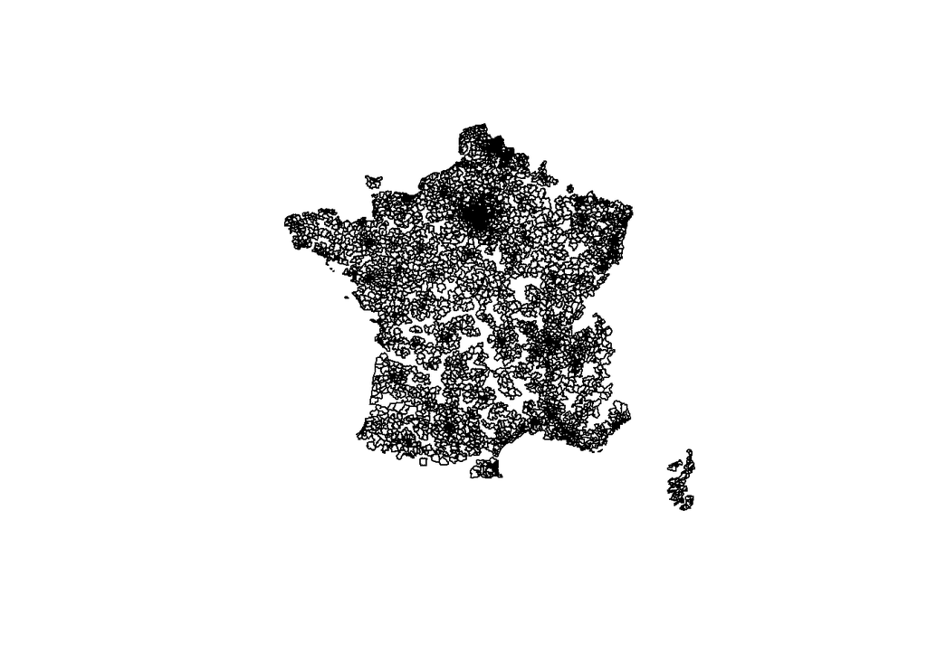

```r
VilleAAV2 <- VilleAAV %>%
  left_join(Envie_ID, by = c("LIBAAV2020"))%>%
  st_as_sf(sf_column_name = "geometry")
plot(st_geometry(VilleAAV2))
```

**Option 2**  
On aggrège les AAV et on prend leurs points centraux.

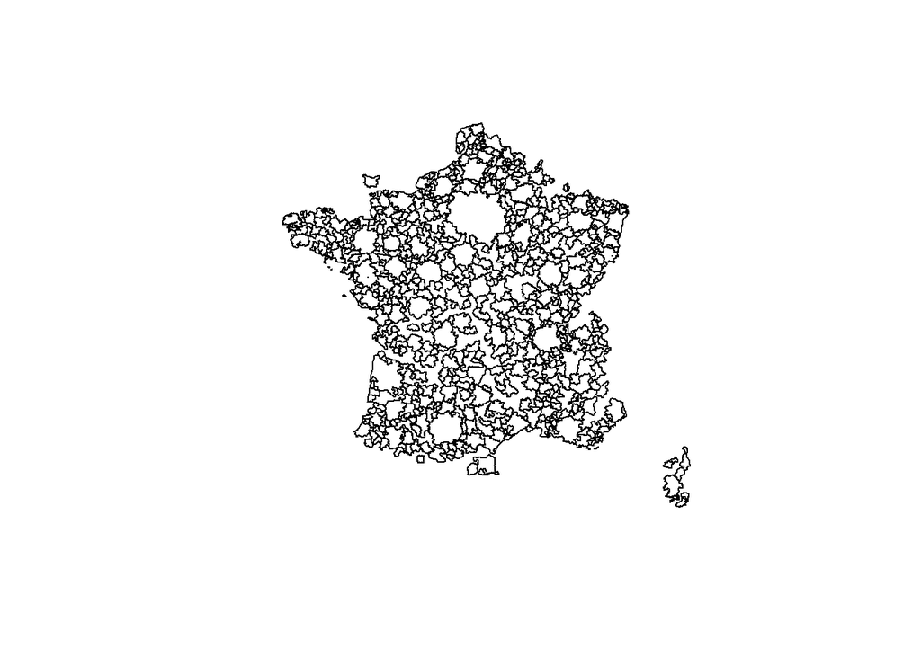

```r
VilleAAV3 <- VilleAAV2 %>%
  group_by(LIBAAV2020) %>%
  summarise_if(is.numeric,min)
plot(st_geometry(VilleAAV3))
```

3. Je récupère les points centraux de toutes les zones, à partir duquel on calcule les distances.

**Pour tous les codes postaux :**

```r
Envie_Geo2$centroid <- st_centroid(Envie_Geo2$geometry)
```

**Pour le point de destination :**

*Si option 1*  
On prend comme destination le code postal le **plus proche** de la ville de référence

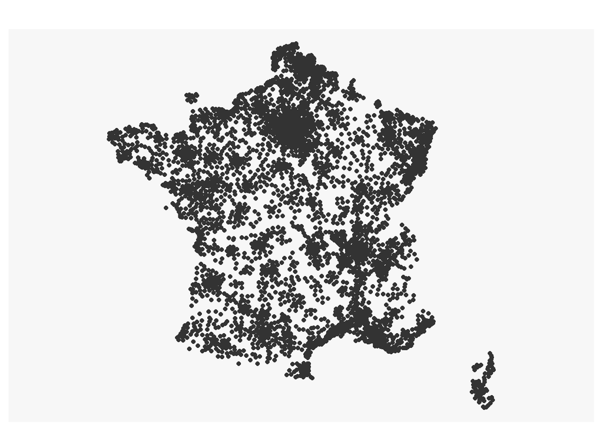

```r
VilleAAV2$centroid <- st_centroid(VilleAAV2$geometry)
mf_map(st_centroid(VilleAAV2$geometry))
```

*Si option 2*  
On prend comme destination le **point central** de l’AAV.

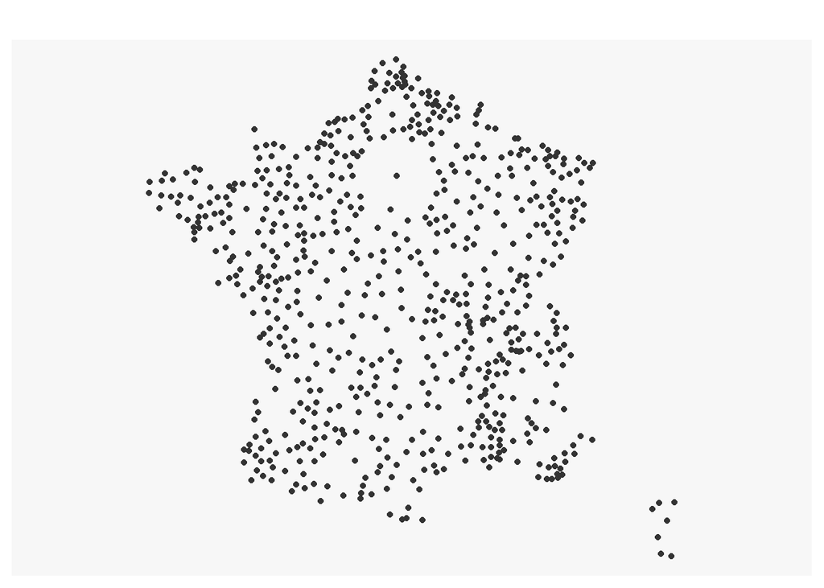

```r
VilleAAV3$centroid <- st_centroid(VilleAAV3$geometry)
mf_map(st_centroid(VilleAAV3$geometry))
```

4. Je calcule les distances entre tous les codes postaux et tous les centre d’AAV

```r
# Option 2 pour l'instant
distance <- st_distance(Envie_Geo2$centroid, VilleAAV3$centroid)
distance <- as.data.frame.matrix(distance)
colnames(distance) <- VilleAAV3$LIBAAV2020
distance$LIB = Envie_Geo2$LIB
```

```r
distance_AAV <- distance %>%
  pivot_longer(1:667,
               names_to = "Ville",
               values_to = "Dist_AAV") %>%
  group_by(LIB)              %>%
  arrange(Dist_AAV)          %>%
  # Pour prendre la ville la plus proche
  # slice(1)                   %>%
  mutate(Dist_AAV = ifelse(LIB == Ville, 0, Dist_AAV)) %>%
  left_join(select(Envie_Geo2, LIB, LIBAAV2020, ID, DEP)) %>%
  filter(Ville == LIBAAV2020) %>%
  select(-Ville) %>%
  select(1:5) %>%
  as.data.frame() %>%
  distinct() %>%
  # Pour les doublons avec deux destinations, on garde plus petite
  group_by(ID) %>%
  arrange(Dist_AAV) %>%
  slice(1)
```

```r
Envie_Geo3 <- Envie_Geo2 %>%
  left_join(distance_AAV)
st_crs(Envie_Geo3)$units
```

```
[1] "m"
```

```r
Dist_Manq <- Envie_Geo3 %>%
  filter(is.na(Dist_AAV))
table(Dist_Manq$LIBAAV2020)
```

```
Bâle - Saint-Louis (partie française)    Commune hors attraction des villes
                                   13                                  1149
Freyming-Merlebach (partie française) Genève - Annemasse (partie française)
                                    2                                    26
           Hendaye (partie française)           Lausanne (partie française)
                                    2                                     1
        Luxembourg (partie française)         Sarrebruck (partie française)
                                   36                                     4
       Wissembourg (partie française)
                                    1
```

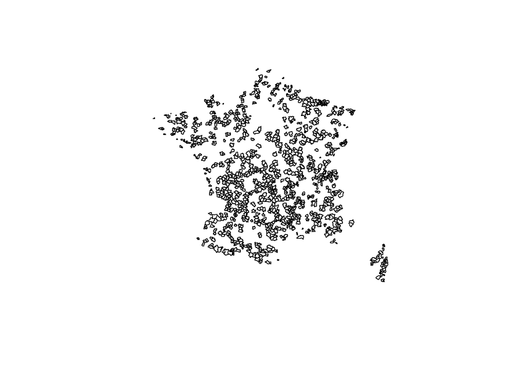

```r
plot(st_geometry(Dist_Manq))
```

## Périmètre autour du code postal

### Fonctionnement

```r
Geo_Peri <- Envie_Geo3 %>%
  select(1:8,24) %>%
  filter(is.na(LIB) == FALSE)
head(Geo_Peri)
```

```
Simple feature collection with 6 features and 8 fields
Geometry type: MULTIPOLYGON
Dimension:     XY
Bounding box:  xmin: 835049 ymin: 6524887 xmax: 917925 ymax: 6582515
Projected CRS: RGF93 v1 / Lambert-93
# A tibble: 6 × 9
  ID    LIB                 DEP      Ind    Men Ind_18_24 Ind_25_39 Ind_18_39
  <chr> <chr>               <chr>  <dbl>  <dbl>     <dbl>     <dbl>     <dbl>
1 01000 Bourg-en-Bresse     01    45498. 21920.     3800.     7967.    11767.
2 01090 Montmerle-sur-Saône 01     9196.  3533.      629.     1500.     2129
3 01100 Oyonnax             01    33632  13682.     2568.     5879.     8446.
4 01110 Hauteville-Lompnes  01     5634.  2711.      367.      863.     1230.
5 01120 Montluel            01    19145   7325.     1557.     3579.     5137.
6 01130 Nantua              01     6801   2932.      494      1201      1695
# ℹ 1 more variable: geometry <MULTIPOLYGON [m]>
```

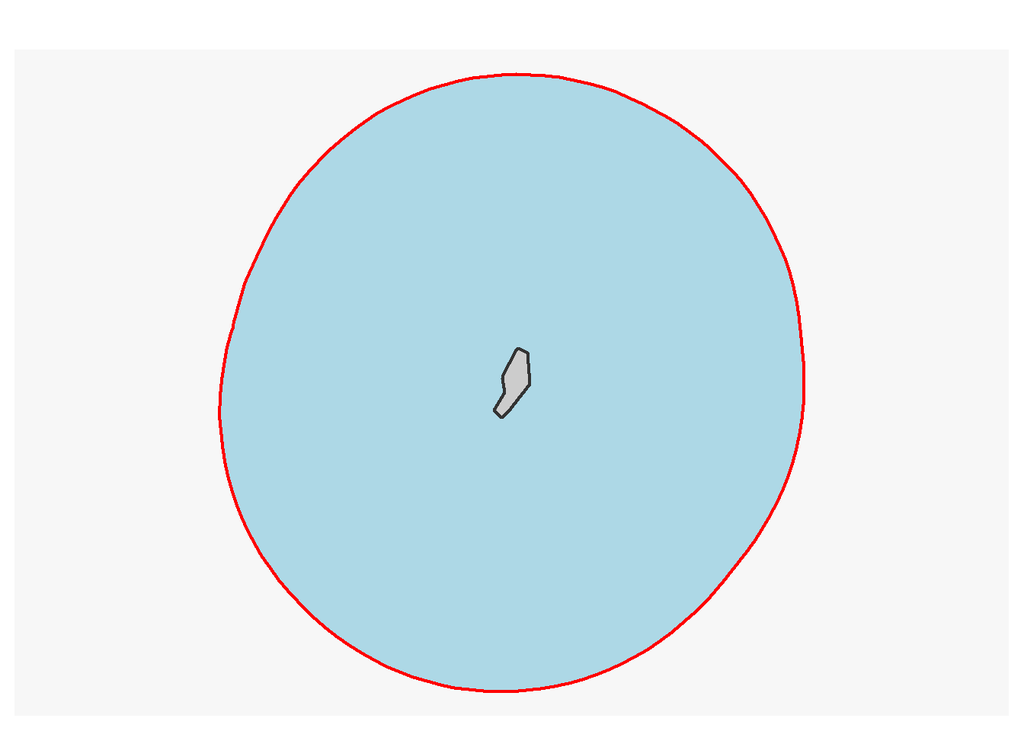

```r
ried <- Geo_Peri[Geo_Peri$ID == "68400", ]
# Cercle de 20km autour de Riedisheim
ried_cercle <- st_buffer(x = ried, dist = 20000)
mf_map(ried_cercle, col = "lightblue", lwd=2, border = "red")
mf_map(ried, add = TRUE, lwd = 2)
```

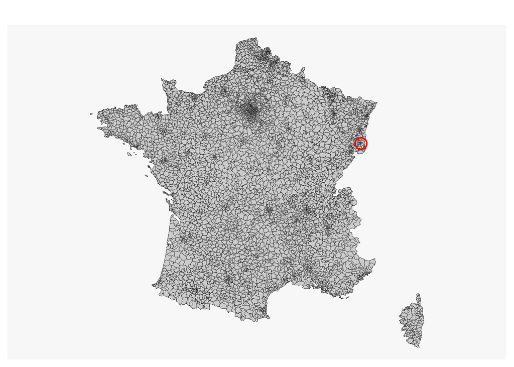

```r
ried_zone <- st_geometry(ried) |>
  st_centroid() |>
  st_buffer(20000)
mf_map(Geo_Peri)
mf_map(ried_zone, border = "red", col = NA, lwd = 2, add = TRUE)
```

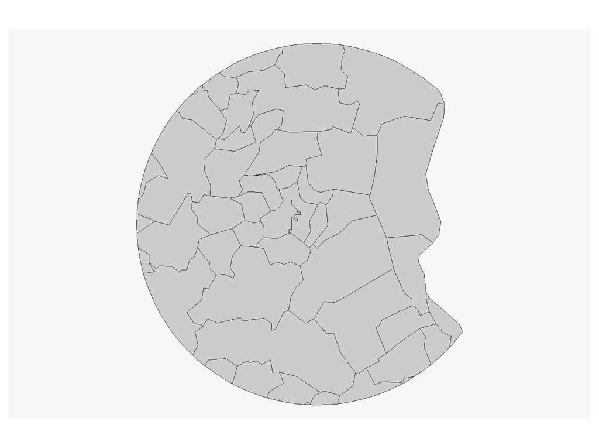

```r
ried_20km <- st_intersection(x = Geo_Peri, y = ried_zone)
mf_map(ried_20km)
```

```r
ried_20kmb <- ried_20km        %>%
  summarise_if(is.numeric,sum) %>%
  mutate(ID = "68400") %>%
  rename(Aire20km_Ind = Ind,
         Aire20km__Ind_18_24 = Ind_18_24,
         Aire20km__Ind_25_39 = Ind_25_39,
         Aire20km__Ind_18_39 = Ind_18_39)
```

### Boucle pour toutes les zones ?

```r
Envie_Geo4 <- data.frame(Aire20km_Ind = NA,
                         Aire20km__Ind_18_24 = NA,
                         Aire20km__Ind_25_39 = NA,
                         Aire20km__Ind_18_39 = NA)

for (i in Geo_Peri$ID) {

  hop <- Geo_Peri   %>%
    filter(ID == i) %>%
    st_geometry()   %>%
    st_centroid()   %>%
    st_buffer(20000)

  hop_20km <- st_intersection(x = Geo_Peri, y = hop) %>%
    summarise_if(is.numeric,sum) %>%
    mutate(ID = i) %>%
    rename(Aire20km_Ind = Ind,
           Aire20km__Ind_18_24 = Ind_18_24,
           Aire20km__Ind_25_39 = Ind_25_39,
           Aire20km__Ind_18_39 = Ind_18_39)

  Envie_Geo4 <- Envie_Geo4 %>%
    bind_rows(hop_20km)
}
```

### Test d’optimisation

```r
# Création de la fonction pour calculer les indicateurs pour une géométrie donnée
calc_indicators <- function(x) {

  hop <- Geo_Peri   %>%
    filter(ID == x) %>%
    st_geometry()   %>%
    st_centroid()   %>%
    st_buffer(20000)

  hop_20km <- st_intersection(x = Geo_Peri, y = hop) %>%
    st_set_geometry(NULL)      %>%
    summarise_if(is.numeric,sum) %>%
    mutate(ID = x) %>%
    rename(Aire20km_Ind = Ind,
           Aire20km_Ind_18_24 = Ind_18_24,
           Aire20km_Ind_25_39 = Ind_25_39,
           Aire20km_Ind_18_39 = Ind_18_39) %>%
    select(ID, everything())
  return(hop_20km)
}

calc_indicators(x = "68400")

# Mini_Geo <- Geo_Peri[c(1:100),]

# Combiner les résultats en un seul data frame
Envie_Geo4 <- do.call(rbind, lapply(Geo_Peri$ID, calc_indicators ))

hip <- Envie_Geo4 %>% group_by(ID) %>% summarise(Eff = n()) %>%
  filter(Eff > 1)
hiphip <- Envie_Geo3 %>%
  filter(ID %in% hip$ID)
```

```r
Envie_Geo4b <- Envie_Geo4 %>%
  select(-Men) %>%
  rename(Aire20km_Ind_18_24 = Aire20km__Ind_18_24,
         Aire20km_Ind_25_39 = Aire20km__Ind_25_39,
         Aire20km_Ind_18_39 = Aire20km__Ind_18_39)

Envie_IndicGeo <- Envie_Geo3 %>%
  left_join(Envie_Geo4b) %>%
  st_set_geometry(NULL)      %>%
  select(-c(centroid))

class(Envie_IndicGeo)
write.xlsx(Envie_IndicGeo, "IndicateurGeographique.xlsx")
```

```r
results_list <- map(Mini_Geo$ID, calc_indicators)

# Combiner les résultats en un seul data frame
Envie_Geo4b <- bind_rows(results_list)
```

### Benchmark vitesse.

```r
library(microbenchmark)
library(purrr)

# Définir la fonction calc_indicators comme précédemment
Mini_Geo <- Geo_Peri[c(1:100),]

# Benchmarking
results <- microbenchmark(
  for_loop = {
    Envie_Geo4 <- data.frame(Aire20km_Ind = NA,
                             Aire20km__Ind_18_24 = NA,
                             Aire20km__Ind_25_39 = NA,
                             Aire20km__Ind_18_39 = NA)
    for (i in Mini_Geo$ID) {
      hop <- Mini_Geo %>%
        filter(ID == i) %>%
        st_geometry() %>%
        st_centroid() %>%
        st_buffer(20000)

      hop_20km <- st_intersection(x = Mini_Geo, y = hop) %>%
        summarise_if(is.numeric, sum) %>%
        mutate(ID = i) %>%
        rename(Aire20km_Ind = Ind,
               Aire20km__Ind_18_24 = Ind_18_24,
               Aire20km__Ind_25_39 = Ind_25_39,
               Aire20km__Ind_18_39 = Ind_18_39)

      Envie_Geo4 <- bind_rows(Envie_Geo4, hop_20km)
    }
  },
  lapply_function = {
    results_list <- lapply(Mini_Geo$ID, calc_indicators)
    Envie_Geo4 <- bind_rows(results_list)
  },
  purrr_map = {
    results_list <- map(Mini_Geo$ID, calc_indicators)
    Envie_Geo4 <- bind_rows(results_list)
  },
  times = 10  # Nombre de répétitions pour chaque méthode
)

# Afficher les résultats
print(results)
```

[output not shown]